# notebook_and_plotly_demo slides

## Jupyter (Julia / Python / R) Notebooks

Notebooks are web pages that allow for code to be run from interactively in the web browser.

I would venture to say that Jupyter is the standard among data scientists using python.

Notebooks are a great way to:

- Explore data
- Prototype code
- Walk people through your work
- Act as an interactive manual
- Repeat scatterbrained analyses later on

**This is one of the best ways to figure out what your data look like**

[figure not shown]

```python
!ls -l dataSets
```

```
total 4208
-rw-r--r--@ 1 alex_m  staff  570129 Aug  7 21:01 LBAthym_x-126_X-123.5_y44_Y46_nx3601_ny1801.xyz
-rw-r--r--@ 1 alex_m  staff  790497 Aug  7 20:28 TATsstaS3day_20180721120000_x-126_X-123.5_y44_Y46_nx2147483647_ny2147483647.xyz
-rw-r--r--@ 1 alex_m  staff  788762 Aug  7 21:11 TMWchlaS8day_20180721000000_x-126_X-123.5_y44_Y46_nx2147483647_ny2147483647.xyz
```

```python
import numpy
import scipy.interpolate
import pandas

%matplotlib notebook
from matplotlib import pyplot
```

```python
bathData = pandas.read_table('dataSets/LBAthym_x-126_X-123.5_y44_Y46_nx3601_ny1801.xyz',
                               names=['Longitude [deg]', 'Latitude [deg]', 'Depth [m]'])
chloroData = pandas.read_table('dataSets/TMWchlaS8day_20180721000000_x-126_X-123.5_y44_Y46_nx2147483647_ny2147483647.xyz',
                               names=['Longitude [deg]', 'Latitude [deg]', 'Chlorophyll [mg/m^3]]'])
tempData = pandas.read_table('dataSets/TATsstaS3day_20180721120000_x-126_X-123.5_y44_Y46_nx2147483647_ny2147483647.xyz',
                               names=['Longitude [deg]', 'Latitude [deg]', 'Temperature [C]'])
bathData.head()
```

|  | Longitude [deg] | Latitude [deg] | Depth [m] |
| --- | --- | --- | --- |
| 0 | -126.000000 | 44 | -2994 |
| 1 | -125.983333 | 44 | -2995 |
| 2 | -125.966667 | 44 | -2996 |
| 3 | -125.950000 | 44 | -2997 |
| 4 | -125.933333 | 44 | -2998 |

```python
newportCoords = [-124.0535, 44.6368]
fishCoords = [-125.5, 44.5]
```

```python
depthInterp = scipy.interpolate.interp2d(bathData['Longitude [deg]'],
                                         bathData['Latitude [deg]'],
                                         bathData['Depth [m]'])

profileLong = numpy.linspace(fishCoords[0],newportCoords[0],1000)
profileLat = numpy.linspace(fishCoords[1],newportCoords[1],1000)
profileDepth = [depthInterp(longi,lati)[0] for longi,lati in zip(profileLong,profileLat)]

profileDepth
```

[output not shown]

[output cut: 945 more lines]

[output not shown]

Map the data to a grid

Wait, how do I do that???

```python
numpy.meshgrid?
```

```python
bathLat = numpy.unique(bathData['Latitude [deg]'])
bathLong = numpy.unique(bathData['Longitude [deg]'])
mapLong, mapLat = numpy.meshgrid(bathLong,bathLat)
mapDepth = bathData['Depth [m]'].reshape(len(bathLat),len(bathLong))*-3.3
```

```python
coastLong = []
coastLat = []

for jdx,latDepth in enumerate(mapDepth):
    idx = numpy.where(latDepth<0.0)[0][0]
    coastLat.append(bathLat[jdx])
    coastLong.append(bathLong[idx])
```

Now make a pretty plot

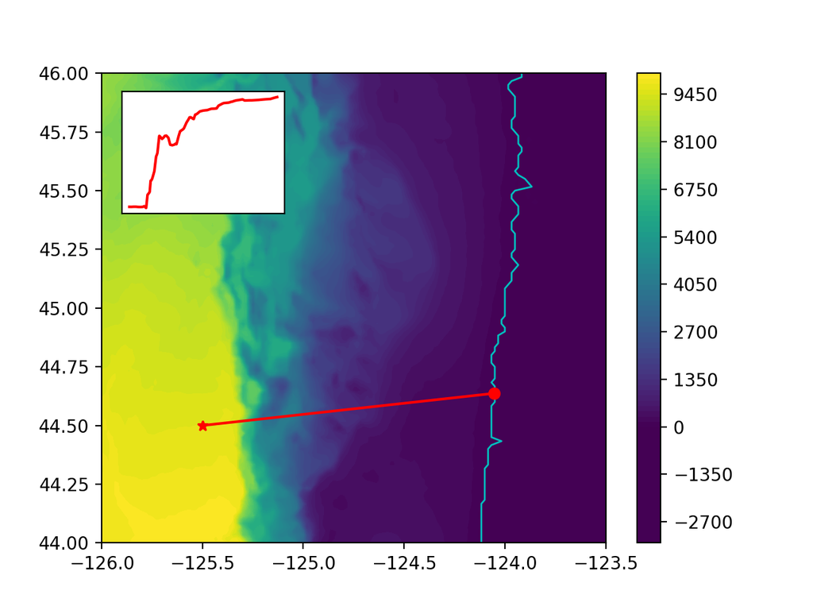

```
[]
```

```python
pyplot.figure()
cont = pyplot.contourf(bathLong,bathLat,mapDepth,100,vmin=0)
pyplot.colorbar(cont)
pyplot.plot(coastLong,coastLat,'-c',lw=1)
pyplot.plot(newportCoords[0],newportCoords[1],'ro',label='Newport')
pyplot.plot(fishCoords[0],fishCoords[1],'r*',label='Fish')
pyplot.plot([newportCoords[0],fishCoords[0]],[newportCoords[1],fishCoords[1]],'r-')
a = pyplot.axes([.15, .65, .2, .2])
a.plot(profileDepth,color='r')
a.get_xaxis().set_ticks([])
a.get_yaxis().set_ticks([])
```

## Some Great Examples

http://readiab.org/book/latest/ https://github.com/jupyter/jupyter/wiki/A-gallery-of-interesting-Jupyter-Notebooks http://nbviewer.jupyter.org/gist/rpmuller/5920182

## Plotly

Plotly is a visualization tool built with Java Script using D3 (Data Driven Documents). It is basically an interface to a pretty plot maker.

- View in notebook, or as independent html
- Cross platform (javascript, python, R, matlab)
- Just use examples and docs (extremely rich, built with jupyter notebooks)
- Awesome for playing with visual data
- *Can be slow (lots of data in HTML)*

```python
from plotly.offline import download_plotlyjs, init_notebook_mode, plot, iplot
from plotly import tools
import plotly.graph_objs as go

init_notebook_mode(connected=True)
```

Let's play with some dummy data!

```python
xData = numpy.linspace(0.0,6.0,100)
sineData = numpy.sin(xData)
randSineData = sineData*(1.1-0.2*numpy.random.rand(100))
```

First, the `matplotlib` version

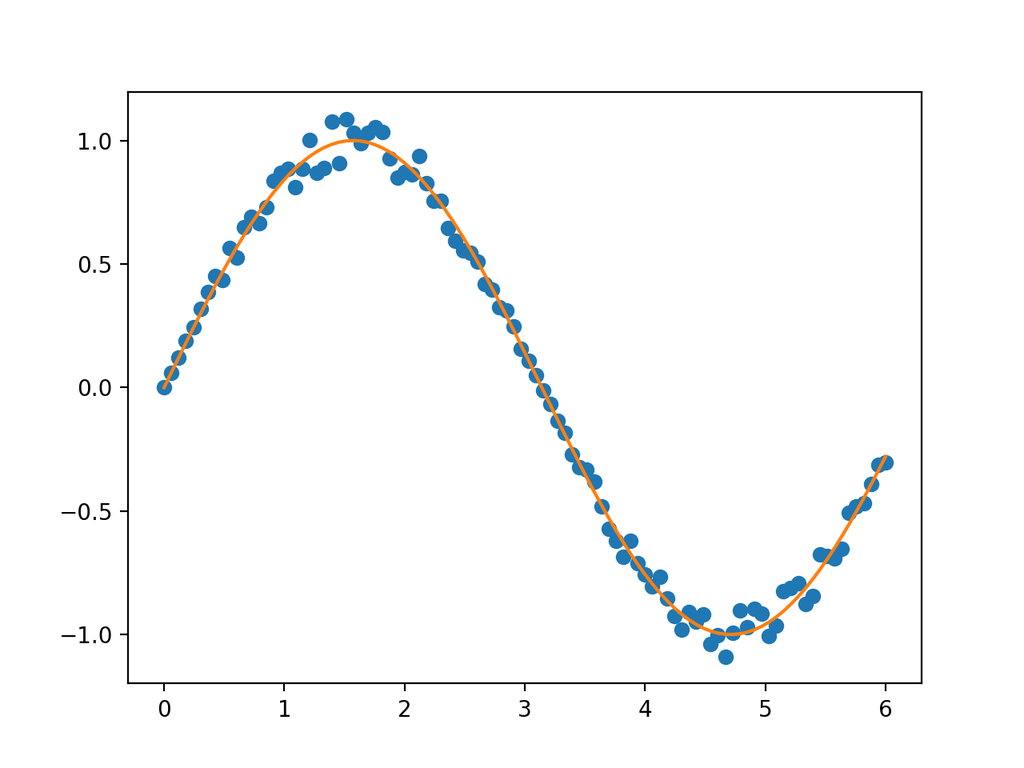

```python
fig = pyplot.figure()
pyplot.plot(xData,randSineData,'o')
pyplot.plot(xData,sineData,'-')
```

Now `plotly`

```python
trace = go.Scatter(x=xData,y=sineData,name='Sine')
points = go.Scatter(x=xData,y=randSineData,mode='markers',name='Sine+Noise')
iplot([points,trace])
```

[interactive chart not shown]

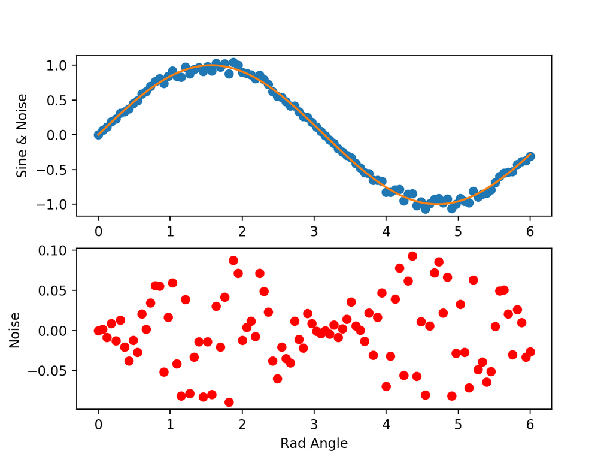

```
Text(0.5,0,'Rad Angle')
```

```python
fig = pyplot.figure()
dataPlot = fig.add_subplot(211)
dataPlot.plot(xData,randSineData,'o')
dataPlot.plot(xData,sineData,'-')
residPlot = fig.add_subplot(212)
residPlot.plot(xData,randSineData-sineData,'ro')

dataPlot.set_ylabel('Sine & Noise')
residPlot.set_ylabel('Noise')
residPlot.set_xlabel('Rad Angle')
```

```python
trace = go.Scatter(x=xData,y=sineData,name='Sine')
points = go.Scatter(x=xData,y=randSineData,mode='markers',name='Sine+Noise')
resid = go.Scatter(x=xData,y=randSineData-sineData,mode='markers',
                   marker=dict(color='Red'),showlegend=False)

fig = tools.make_subplots(rows=2, cols=1)
fig.append_trace(points,1,1)
fig.append_trace(trace,1,1)
fig.append_trace(resid,2,1)

fig['layout'].update(height=600, width=600)
fig['layout']['yaxis1'].update(title='Sine & Noise')
fig['layout']['yaxis2'].update(title='Noise')
fig['layout']['xaxis2'].update(title='Rad Angle')

iplot(fig) # in notebook
plot(fig) # in html
```

```
This is the format of your plot grid:
[ (1,1) x1,y1 ]
[ (2,1) x2,y2 ]
```

[interactive chart not shown]

```
'file:///Users/alex_m/Documents/Loc_Codes/notebookPlotlyDemo/temp-plot.html'
```

What does this data structure look like?

```python
print fig
```

[output not shown]

[output cut: 74 more lines]

[output not shown]

Let's compare against our fancy `matplotlib` chart

```python
depth = go.Contour(x=bathLong,y=bathLat,z=mapDepth,colorscale='Viridis',
                  contours=dict(start=0,end=10e3,size=100,showlines=False))
newport = go.Scatter(x=[newportCoords[0]],y=[newportCoords[1]],mode='markers',
                     marker=dict(color='red',symbol='circle',size=10),
                    name='Newport')
fish = go.Scatter(x=[newportCoords[0],fishCoords[0]],y=[newportCoords[1],fishCoords[1]],
                    mode='lines',line=dict(color='red'),
                    name='Fish')
line = go.Scatter(x=[fishCoords[0]],y=[fishCoords[1]],mode='markers',
                     marker=dict(color='red',symbol='star',size=10),
                     showlegend=False)
profile = go.Scatter(y=profileDepth,xaxis='x2',yaxis='y2',mode='line',line=dict(color='red'),
                     showlegend=False)
coast = go.Scatter(x=coastLong,y=coastLat,mode='line',line=dict(color='cyan'),showlegend=False)
data = [depth,coast,newport,fish,line,profile]
layout = go.Layout(
    legend=dict(orientation="h"),
    xaxis2=dict(domain=[0.05,0.45],anchor='x2',showticklabels=False),
    yaxis2=dict(domain=[0.55,0.9],anchor='y2',showticklabels=False)
)
fig = go.Figure(data=data,layout=layout)
iplot(fig)
```

[interactive chart not shown]

And SO much more: **https://plot.ly/python/**

We can also make this a presentation!

```python
!jupyter nbconvert notebook_and_plotly_demo.ipynb --to slides --post serve
```

```
[NbConvertApp] Converting notebook notebook_and_plotly_demo.ipynb to slides
[NbConvertApp] Writing 1166275 bytes to notebook_and_plotly_demo.slides.html
[NbConvertApp] Redirecting reveal.js requests to https://cdnjs.cloudflare.com/ajax/libs/reveal.js/3.1.0
Serving your slides at http://127.0.0.1:8000/notebook_and_plotly_demo.slides.html
Use Control-C to stop this server
WARNING:tornado.access:404 GET /custom.css (127.0.0.1) 6.19ms
WARNING:tornado.access:404 GET /custom.css (127.0.0.1) 0.90ms
^C
Interrupted
```